# Phân tích Trễ hạn Giao hàng Logistics (Logistics Late Delivery Analysis)

## Mục tiêu (Goal)

Thiết lập Notebook, import các thư viện cần thiết, thực hiện đọc và làm sạch dữ liệu từ dataset `DataCoSupplyChainDataset.csv`, sau đó thực hiện biến đổi dữ liệu (Feature Engineering) chuẩn bị cho các bước phân tích tiếp theo.

## Bước 2: Đọc và Làm sạch Dữ liệu (Data Loading & Cleaning)

Đọc dữ liệu từ file CSV của DataCo và thực hiện lọc bỏ các đơn hàng bị hủy (`CANCELED`) hoặc nghi ngờ gian lận (`SUSPECTED_FRAUD`) để đảm bảo chất lượng phân tích.

```
Original shape: (180519, 53), Cleaned shape: (172765, 53)
```

## Bước 3: Chuyển đổi định dạng Ngày tháng và Feature Engineering

Chuyển đổi các cột ngày tháng sang định dạng datetime và tạo thêm các cột chỉ số cần thiết như `Shipping_Delay_Days` (chênh lệch giữa số ngày giao hàng thực tế và số ngày dự kiến), `Order_Month` và `Order_DayOfWeek` phục vụ phân tích mùa vụ.

## Bước 4: Kiểm chứng dữ liệu đã làm sạch (Data Validation)

Kiểm tra tính toàn vẹn của dữ liệu sau khi biến đổi, đảm bảo không có giá trị trống (NaN/Null) trong trường `Shipping_Delay_Days`.

```
Dữ liệu đã sẵn sàng để phân tích.
```

## Bước 5: Tính toán các chỉ số KPIs nền tảng (Baseline KPIs Calculation)

Chúng ta sẽ tính toán các chỉ số đo lường hiệu suất (KPIs) vận hành giao hàng cốt lõi:

- **Tỷ lệ giao hàng muộn (Late Delivery Rate - LDR)**: Phần trăm đơn hàng bị giao trễ so với kế hoạch (thời gian thực tế > dự kiến).
- **Số ngày giao thực tế trung bình (Average Actual Shipping Days)**: Thời gian trung bình để hoàn thành việc giao hàng.
- **Số ngày giao muộn trung bình (Average Delay Days)**: Thời gian trễ trung bình của các đơn hàng bị giao muộn.

```
Late Delivery Rate (LDR): 57.29%
Average Actual Shipping Days: 3.50 ngày
Average Delay Days: 1.62 ngày
```

## Bước 6: Phân bổ chênh lệch thời gian giao hàng (Delay Distribution Analysis)

Vẽ biểu đồ phân bổ thời gian lệch ngày giữa thực tế so với kế hoạch (`Shipping_Delay_Days`). Mốc nét đứt màu đỏ (giá trị 0) biểu thị việc giao hàng đúng hạn. Các giá trị nằm bên phải mốc 0 là các đơn hàng bị giao muộn.

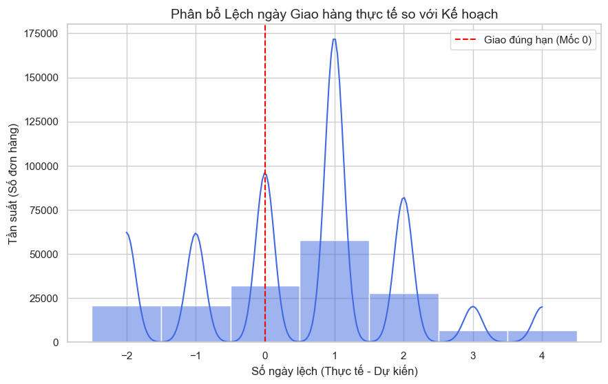

## Bước 7: Phân tích chẩn đoán theo Phương thức vận chuyển (Shipping Mode)

Phương thức vận chuyển đóng vai trò quan trọng trong việc quyết định thời gian và chất lượng giao hàng. Phần này thực hiện phân tích tỷ lệ giao hàng muộn (LDR) và thời gian giao hàng trung bình thực tế cho từng phương thức.

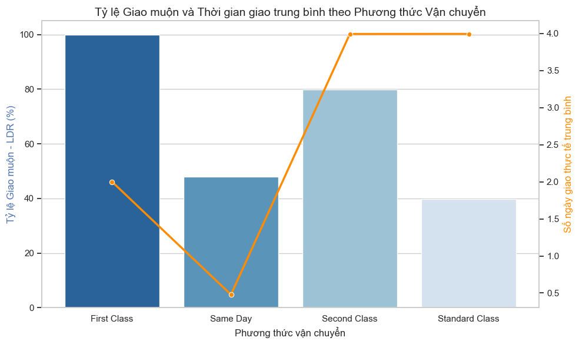

## Bước 8: Phân tích chẩn đoán theo Địa lý (Market & Order Region)

Yếu tố địa lý (Khu vực đặt hàng) ảnh hưởng lớn đến thời gian vận chuyển do khoảng cách địa lý và quy trình hải quan, kho bãi tại từng khu vực. Dưới đây là top 15 khu vực có tỷ lệ giao muộn cao nhất (chỉ xét các khu vực có trên 100 đơn hàng).

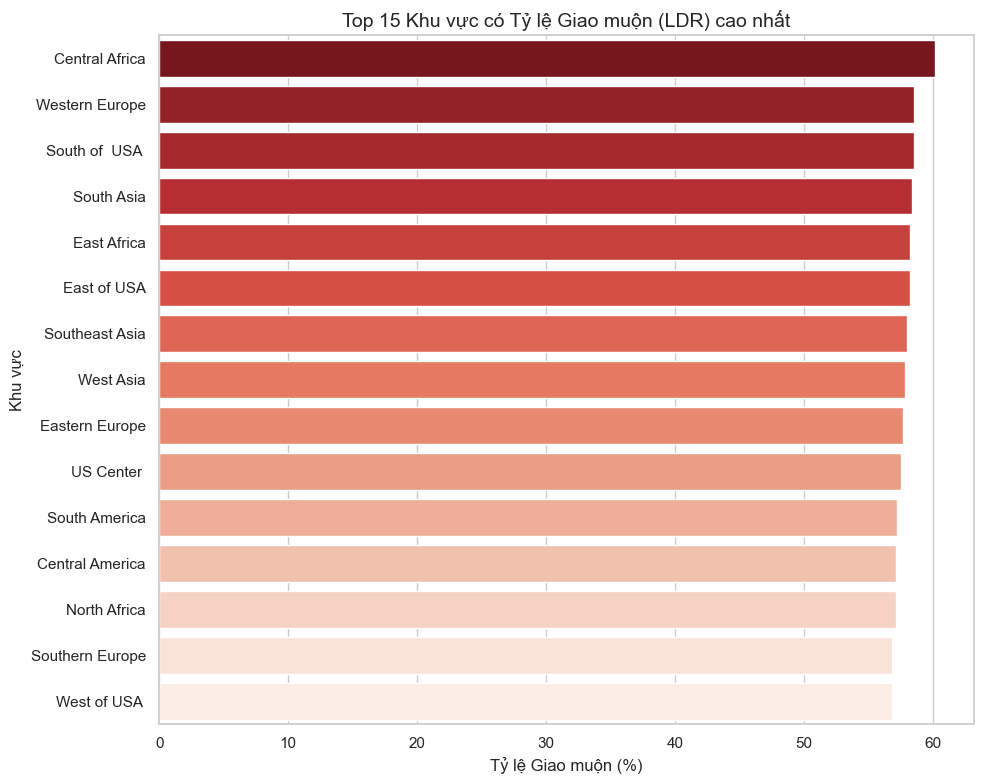

## Bước 9: Phân tích chẩn đoán theo Danh mục Sản phẩm (Category)

Một số loại hàng hóa đặc thù (như hàng cồng kềnh, hàng dễ vỡ hoặc dễ cháy nổ) có quy trình đóng gói và vận chuyển phức tạp hơn. Phần này phân tích 10 danh mục sản phẩm có tỷ lệ giao muộn cao nhất.

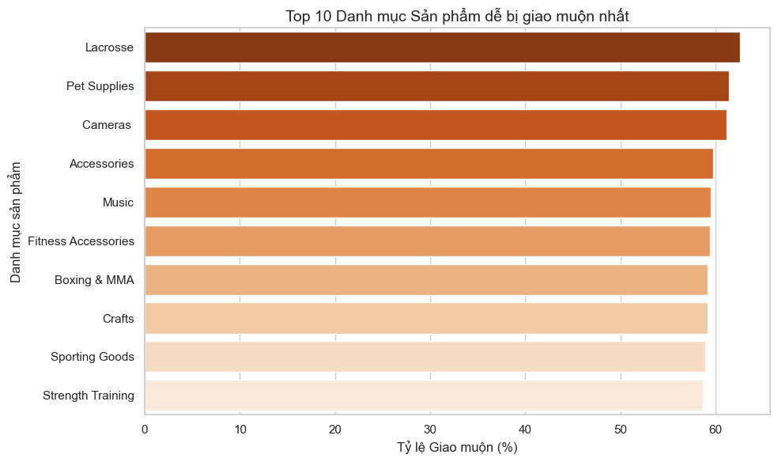

## Bước 10: Phân tích chẩn đoán theo Mùa vụ (Yếu tố thời gian)

Nhu cầu mua sắm và vận chuyển biến động mạnh theo các tháng trong năm (đặc biệt vào dịp lễ hội, cuối năm). Dưới đây là biểu đồ thể hiện sự biến động của tỷ lệ giao muộn (LDR) theo từng tháng.

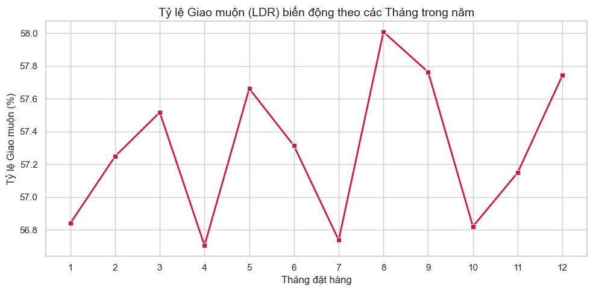

## Bước 11: Phân tích Tương quan & Kiểm chứng Thống kê (Correlation & Statistical Validation)

Trong phần này, chúng ta sẽ thực hiện phân tích định lượng nâng cao để đánh giá tác động tài chính của việc giao hàng muộn, mối liên hệ giữa các chương trình khuyến mãi/chiết khấu lớn với rủi ro giao muộn, và thực hiện các kiểm định thống kê Chi-Square để xác minh tính độc lập.

### 11.1. So sánh tài chính giữa Giao muộn và Giao đúng hạn

Tính toán và so sánh lợi nhuận trung bình (`Benefit per order`), doanh số trung bình (`Sales`), và tổng lợi nhuận giữa nhóm đơn hàng giao muộn vs giao đúng hạn.

```
Bảng so sánh chỉ số tài chính theo tình trạng giao hàng:
   Is_Late  Avg_Profit   Avg_Sales  Total_Profit
0    False   22.583197  204.478159  1.666369e+06
1     True   21.621707  203.344163  2.140052e+06
```

### 11.2. Mối liên hệ giữa Chiết khấu và Tỷ lệ giao muộn (LDR)

Phân loại mức chiết khấu (`Order Item Discount Rate`) thành các khoảng (bin) và tính tỷ lệ giao muộn (LDR) tương ứng để xem các đơn hàng khuyến mãi lớn có rủi ro giao muộn cao hơn không.

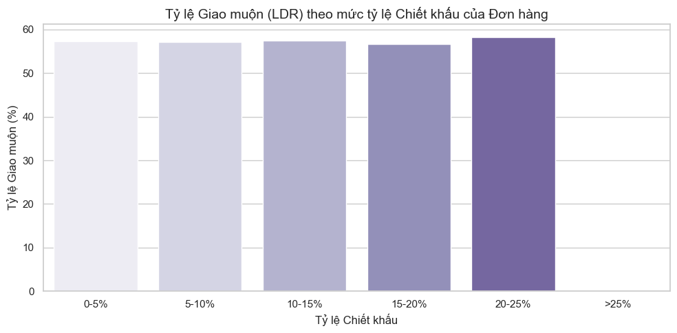

### 11.3. Kiểm định Chi-Square kiểm chứng thống kê độc lập

Áp dụng kiểm định Chi-Square để đánh giá mức độ phụ thuộc có ý nghĩa thống kê giữa phương thức vận chuyển, khu vực đặt hàng với tình trạng giao muộn (`Is_Late`).

```
Kiểm định Chi-Square (Shipping Mode vs Late Delivery): p-value = 0.0000e+00
=> Phương thức vận chuyển và tình trạng giao muộn có mối liên hệ ý nghĩa thống kê (p < 0.05)

Kiểm định Chi-Square (Order Region vs Late Delivery): p-value = 5.8474e-08
=> Khu vực đặt hàng và tình trạng giao muộn có mối liên hệ ý nghĩa thống kê (p < 0.05)
```

# Mục Phản biện từ Góc nhìn của Risk Analyst (Critique & Limitations)

Dưới góc nhìn của một Chuyên viên Phân tích Rủi ro (Risk Analyst), việc phân tích hiệu suất logistics cần đi kèm với việc đánh giá tính toàn vẹn của dữ liệu và hiểu rõ các giới hạn vốn có của bộ dữ liệu để tránh đưa ra các quyết định vận hành sai lệch.

## 1. Xác thực Nhãn Dữ liệu (Data Label Validation)

Trong bộ dữ liệu, trường `Late_delivery_risk` được cung cấp sẵn như một nhãn hệ thống biểu thị đơn hàng có rủi ro giao muộn. Để kiểm chứng tính chính xác và nhất quán của nhãn này, chúng tôi thực hiện đối chiếu nó với công thức tính toán thực tế: `Shipping_Delay_Days > 0` (trong đó `Shipping_Delay_Days = Days for shipping (real) - Days for shipment (scheduled)`).

Đoạn code dưới đây thống kê số lượng dòng dữ liệu có sự không đồng nhất giữa nhãn hệ thống và công thức tính toán thực tế.

```
Số dòng không đồng nhất giữa nhãn hệ thống và công thức tính toán: 0
```

## 2. Giới hạn Dữ liệu (Dataset Limitations)

Mặc dù phân tích trên chỉ ra nhiều điểm nghẽn quan trọng, bộ dữ liệu hiện tại vẫn tồn tại một số giới hạn về mặt thông tin, làm hạn chế khả năng chẩn đoán sâu nguyên nhân gốc rễ (Root Cause Analysis):

- **Thiếu thông tin chi tiết về đơn vị vận chuyển (Carrier Details)**: Bộ dữ liệu không cung cấp tên cụ thể của bên giao nhận thứ ba (3PL) hay các chi tiết về phương tiện giao hàng, khiến chúng ta không thể đánh giá xem tỷ lệ trễ hạn cao ở gói First Class là do năng lực của nhà vận chuyển cụ thể nào.
- **Không có thông tin thời tiết và ngoại cảnh (Weather & External Events)**: Trễ hạn giao hàng chịu ảnh hưởng lớn bởi các yếu tố bất khả kháng như bão, lụt, thiên tai, dịch bệnh,... Việc thiếu các biến số này làm giảm độ chính xác khi dự báo hoặc đánh giá hiệu năng của chuỗi cung ứng.
- **Thiếu thông tin thông quan (Customs Clearance)**: Đối với các đơn hàng xuyên biên giới (đặc biệt là đi các khu vực như Đông Nam Á hay Nam Á), quá trình thông quan hải quan thường là nút thắt cổ chai lớn nhất. Việc thiếu dữ liệu thời gian thông quan khiến chúng ta không phân biệt được trễ hạn là do khâu vận chuyển chặng giữa hay do thủ tục hải quan kéo dài.